# Risk Factor Analysis

## Outcome Variable

**Outcome Variable:** stunted

## Predictor Variables

**Intervention Variable:** gagebrth

**Adjustment Set:**

unadjusted

## Stratifying Variables

The analysis was stratified on these variable(s):

- agecat
- studyid
- country

## Data Summary

| agecat | studyid | country | gagebrth | stunted | n_cell | n |
| --- | --- | --- | --- | --- | --- | --- |
| 6 months | ki1000108-CMC-V-BCS-2002 | INDIA | [273-287) | 0 | 109 | 347 |
| 6 months | ki1000108-CMC-V-BCS-2002 | INDIA | [273-287) | 1 | 38 | 347 |
| 6 months | ki1000108-CMC-V-BCS-2002 | INDIA | <259 | 0 | 26 | 347 |
| 6 months | ki1000108-CMC-V-BCS-2002 | INDIA | <259 | 1 | 21 | 347 |
| 6 months | ki1000108-CMC-V-BCS-2002 | INDIA | [259-273) | 0 | 51 | 347 |
| 6 months | ki1000108-CMC-V-BCS-2002 | INDIA | [259-273) | 1 | 23 | 347 |
| 6 months | ki1000108-CMC-V-BCS-2002 | INDIA | >=287 | 0 | 60 | 347 |
| 6 months | ki1000108-CMC-V-BCS-2002 | INDIA | >=287 | 1 | 19 | 347 |
| 24 months | ki1000108-CMC-V-BCS-2002 | INDIA | [273-287) | 0 | 43 | 350 |
| 24 months | ki1000108-CMC-V-BCS-2002 | INDIA | [273-287) | 1 | 105 | 350 |
| 24 months | ki1000108-CMC-V-BCS-2002 | INDIA | <259 | 0 | 11 | 350 |
| 24 months | ki1000108-CMC-V-BCS-2002 | INDIA | <259 | 1 | 36 | 350 |
| 24 months | ki1000108-CMC-V-BCS-2002 | INDIA | [259-273) | 0 | 16 | 350 |
| 24 months | ki1000108-CMC-V-BCS-2002 | INDIA | [259-273) | 1 | 59 | 350 |
| 24 months | ki1000108-CMC-V-BCS-2002 | INDIA | >=287 | 0 | 31 | 350 |
| 24 months | ki1000108-CMC-V-BCS-2002 | INDIA | >=287 | 1 | 49 | 350 |
| Birth | ki1000108-CMC-V-BCS-2002 | INDIA | [273-287) | 0 | 28 | 90 |
| Birth | ki1000108-CMC-V-BCS-2002 | INDIA | [273-287) | 1 | 7 | 90 |
| Birth | ki1000108-CMC-V-BCS-2002 | INDIA | <259 | 0 | 6 | 90 |
| Birth | ki1000108-CMC-V-BCS-2002 | INDIA | <259 | 1 | 1 | 90 |
| Birth | ki1000108-CMC-V-BCS-2002 | INDIA | [259-273) | 0 | 19 | 90 |
| Birth | ki1000108-CMC-V-BCS-2002 | INDIA | [259-273) | 1 | 3 | 90 |
| Birth | ki1000108-CMC-V-BCS-2002 | INDIA | >=287 | 0 | 21 | 90 |
| Birth | ki1000108-CMC-V-BCS-2002 | INDIA | >=287 | 1 | 5 | 90 |
| 6 months | ki1000108-IRC | INDIA | [273-287) | 0 | 131 | 388 |
| 6 months | ki1000108-IRC | INDIA | [273-287) | 1 | 34 | 388 |
| 6 months | ki1000108-IRC | INDIA | <259 | 0 | 21 | 388 |
| 6 months | ki1000108-IRC | INDIA | <259 | 1 | 19 | 388 |
| 6 months | ki1000108-IRC | INDIA | [259-273) | 0 | 70 | 388 |
| 6 months | ki1000108-IRC | INDIA | [259-273) | 1 | 21 | 388 |

[output cut: 230 more lines]

The following strata were considered:

- agecat: 24 months, studyid: ki1000108-CMC-V-BCS-2002, country: INDIA
- agecat: 24 months, studyid: ki1000108-IRC, country: INDIA
- agecat: 24 months, studyid: ki1017093c-NIH-Crypto, country: BANGLADESH
- agecat: 24 months, studyid: ki1066203-TanzaniaChild2, country: TANZANIA, UNITED REPUBLIC OF
- agecat: 24 months, studyid: ki1101329-Keneba, country: GAMBIA
- agecat: 24 months, studyid: ki1113344-GMS-Nepal, country: NEPAL
- agecat: 24 months, studyid: ki1119695-PROBIT, country: BELARUS
- agecat: 24 months, studyid: ki1135781-COHORTS, country: GUATEMALA
- agecat: 24 months, studyid: ki1135781-COHORTS, country: INDIA
- agecat: 24 months, studyid: ki1135781-COHORTS, country: PHILIPPINES
- agecat: 24 months, studyid: kiGH5241-JiVitA-3, country: BANGLADESH
- agecat: 6 months, studyid: ki1000108-CMC-V-BCS-2002, country: INDIA
- agecat: 6 months, studyid: ki1000108-IRC, country: INDIA
- agecat: 6 months, studyid: ki1000109-EE, country: PAKISTAN
- agecat: 6 months, studyid: ki1000304b-SAS-CompFeed, country: INDIA
- agecat: 6 months, studyid: ki1017093c-NIH-Crypto, country: BANGLADESH
- agecat: 6 months, studyid: ki1066203-TanzaniaChild2, country: TANZANIA, UNITED REPUBLIC OF
- agecat: 6 months, studyid: ki1101329-Keneba, country: GAMBIA
- agecat: 6 months, studyid: ki1113344-GMS-Nepal, country: NEPAL
- agecat: 6 months, studyid: ki1119695-PROBIT, country: BELARUS
- agecat: 6 months, studyid: ki1135781-COHORTS, country: GUATEMALA
- agecat: 6 months, studyid: ki1135781-COHORTS, country: INDIA
- agecat: 6 months, studyid: ki1135781-COHORTS, country: PHILIPPINES
- agecat: 6 months, studyid: kiGH5241-JiVitA-3, country: BANGLADESH
- agecat: Birth, studyid: ki1000108-CMC-V-BCS-2002, country: INDIA
- agecat: Birth, studyid: ki1000108-IRC, country: INDIA
- agecat: Birth, studyid: ki1000109-EE, country: PAKISTAN
- agecat: Birth, studyid: ki1000304b-SAS-CompFeed, country: INDIA
- agecat: Birth, studyid: ki1017093c-NIH-Crypto, country: BANGLADESH
- agecat: Birth, studyid: ki1101329-Keneba, country: GAMBIA
- agecat: Birth, studyid: ki1119695-PROBIT, country: BELARUS
- agecat: Birth, studyid: ki1135781-COHORTS, country: GUATEMALA
- agecat: Birth, studyid: ki1135781-COHORTS, country: INDIA
- agecat: Birth, studyid: ki1135781-COHORTS, country: PHILIPPINES
- agecat: Birth, studyid: kiGH5241-JiVitA-3, country: BANGLADESH

### Dropped Strata

Some strata were dropped due to rare outcomes:

- agecat: Birth, studyid: ki1000108-CMC-V-BCS-2002, country: INDIA
- agecat: 6 months, studyid: ki1000109-EE, country: PAKISTAN
- agecat: Birth, studyid: ki1000109-EE, country: PAKISTAN
- agecat: 6 months, studyid: ki1000304b-SAS-CompFeed, country: INDIA
- agecat: Birth, studyid: ki1000304b-SAS-CompFeed, country: INDIA
- agecat: Birth, studyid: ki1017093c-NIH-Crypto, country: BANGLADESH
- agecat: 6 months, studyid: ki1017093c-NIH-Crypto, country: BANGLADESH
- agecat: 24 months, studyid: ki1017093c-NIH-Crypto, country: BANGLADESH
- agecat: 24 months, studyid: ki1066203-TanzaniaChild2, country: TANZANIA, UNITED REPUBLIC OF
- agecat: Birth, studyid: ki1101329-Keneba, country: GAMBIA
- agecat: 6 months, studyid: ki1113344-GMS-Nepal, country: NEPAL
- agecat: 24 months, studyid: ki1113344-GMS-Nepal, country: NEPAL
- agecat: Birth, studyid: ki1119695-PROBIT, country: BELARUS

## Methods Detail

We’re interested in the causal parameters $E[Y_a]$ for all values of $a \in \mathcal{A}$. These parameters represent the mean outcome if, possibly contrary to fact, we intervened to set all units to have $A=a$. Under the randomization and positivity assumptions, these are identified by the statistical parameters $\psi_a=E_W[E_{Y|A,W}(Y|A=a,W)]$. In addition, we’re interested in the mean of $Y$, $E[Y]$ under no intervention (the observed mean). We will estimate these parameters by using SuperLearner to fit the relevant likelihood factors – $E_{Y|A,W}(Y|A=a,W)$ and $p(A=a|W)$, and then updating our likelihood fit using a joint TMLE.

For unadjusted analyses ($W=\{\}$), initial likelihoods were estimated using Lrnr_glm to estimate the simple $E(Y|A)$ and Lrnr_mean to estimate $p(A)$. For adjusted analyses, a small library containing Lrnr_glmnet, Lrnr_xgboost, and Lrnr_mean was used.

Having estimated these parameters, we will then use the delta method to estimate relative risks and attributable risks relative to a prespecified baseline level of $A$.

# Results Detail

## Results Plots

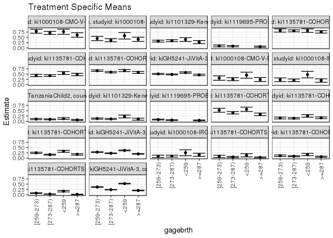

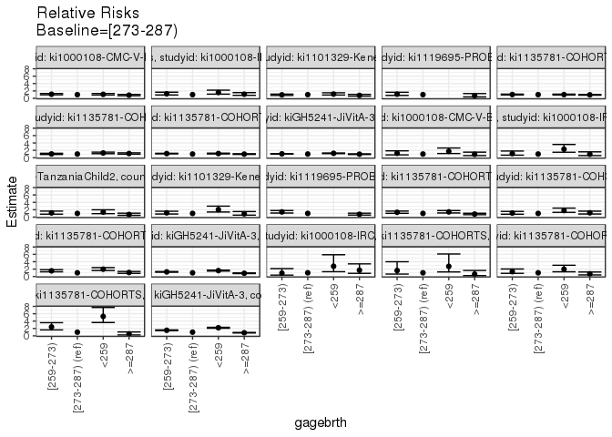

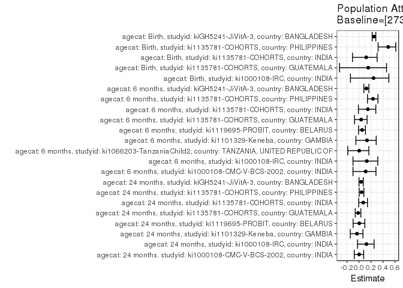

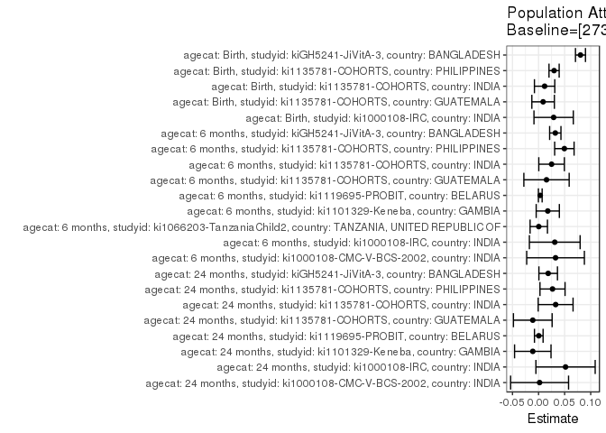

## Results Table

### Parameter: TSM

| agecat | studyid | country | intervention_level | baseline_level | estimate | ci_lower | ci_upper |
| --- | --- | --- | --- | --- | --- | --- | --- |
| Birth | ki1000108-IRC | INDIA | [273-287) | NA | 0.0903226 | 0.0451356 | 0.1355096 |
| Birth | ki1000108-IRC | INDIA | <259 | NA | 0.2500000 | 0.1083597 | 0.3916403 |
| Birth | ki1000108-IRC | INDIA | [259-273) | NA | 0.0804598 | 0.0232260 | 0.1376936 |
| Birth | ki1000108-IRC | INDIA | >=287 | NA | 0.1538462 | 0.0796153 | 0.2280770 |
| Birth | ki1135781-COHORTS | GUATEMALA | [273-287) | NA | 0.0480000 | 0.0214803 | 0.0745197 |
| Birth | ki1135781-COHORTS | GUATEMALA | <259 | NA | 0.1315789 | 0.0555197 | 0.2076382 |
| Birth | ki1135781-COHORTS | GUATEMALA | [259-273) | NA | 0.0777778 | 0.0224014 | 0.1331542 |
| Birth | ki1135781-COHORTS | GUATEMALA | >=287 | NA | 0.0298507 | 0.0063057 | 0.0533958 |
| Birth | ki1135781-COHORTS | INDIA | [273-287) | NA | 0.0843137 | 0.0601895 | 0.1084380 |
| Birth | ki1135781-COHORTS | INDIA | <259 | NA | 0.1657459 | 0.1115523 | 0.2199394 |
| Birth | ki1135781-COHORTS | INDIA | [259-273) | NA | 0.1107266 | 0.0745348 | 0.1469185 |
| Birth | ki1135781-COHORTS | INDIA | >=287 | NA | 0.0607029 | 0.0342392 | 0.0871665 |
| Birth | ki1135781-COHORTS | PHILIPPINES | [273-287) | NA | 0.0314092 | 0.0214472 | 0.0413711 |
| Birth | ki1135781-COHORTS | PHILIPPINES | <259 | NA | 0.1655773 | 0.1315673 | 0.1995874 |
| Birth | ki1135781-COHORTS | PHILIPPINES | [259-273) | NA | 0.0756303 | 0.0576718 | 0.0935887 |
| Birth | ki1135781-COHORTS | PHILIPPINES | >=287 | NA | 0.0162455 | 0.0057168 | 0.0267742 |
| Birth | kiGH5241-JiVitA-3 | BANGLADESH | [273-287) | NA | 0.2401740 | 0.2285553 | 0.2517927 |
| Birth | kiGH5241-JiVitA-3 | BANGLADESH | <259 | NA | 0.5270535 | 0.5088558 | 0.5452513 |
| Birth | kiGH5241-JiVitA-3 | BANGLADESH | [259-273) | NA | 0.3639004 | 0.3486272 | 0.3791736 |
| Birth | kiGH5241-JiVitA-3 | BANGLADESH | >=287 | NA | 0.2019391 | 0.1871108 | 0.2167673 |
| 6 months | ki1000108-CMC-V-BCS-2002 | INDIA | [273-287) | NA | 0.2585034 | 0.1876266 | 0.3293802 |
| 6 months | ki1000108-CMC-V-BCS-2002 | INDIA | <259 | NA | 0.4468085 | 0.3044694 | 0.5891476 |
| 6 months | ki1000108-CMC-V-BCS-2002 | INDIA | [259-273) | NA | 0.3108108 | 0.2052078 | 0.4164138 |
| 6 months | ki1000108-CMC-V-BCS-2002 | INDIA | >=287 | NA | 0.2405063 | 0.1461249 | 0.3348878 |
| 6 months | ki1000108-IRC | INDIA | [273-287) | NA | 0.2060606 | 0.1442650 | 0.2678562 |
| 6 months | ki1000108-IRC | INDIA | <259 | NA | 0.4750000 | 0.3200452 | 0.6299548 |
| 6 months | ki1000108-IRC | INDIA | [259-273) | NA | 0.2307692 | 0.1440920 | 0.3174465 |
| 6 months | ki1000108-IRC | INDIA | >=287 | NA | 0.1956522 | 0.1144853 | 0.2768191 |
| 6 months | ki1066203-TanzaniaChild2 | TANZANIA, UNITED REPUBLIC OF | [273-287) | NA | 0.0952381 | 0.0740110 | 0.1164652 |
| 6 months | ki1066203-TanzaniaChild2 | TANZANIA, UNITED REPUBLIC OF | <259 | NA | 0.1286765 | 0.0888734 | 0.1684796 |

[output cut: 56 more lines]

### Parameter: E(Y)

| agecat | studyid | country | intervention_level | baseline_level | estimate | ci_lower | ci_upper |
| --- | --- | --- | --- | --- | --- | --- | --- |
| Birth | ki1000108-IRC | INDIA | NA | NA | 0.1192412 | 0.0861307 | 0.1523517 |
| Birth | ki1135781-COHORTS | GUATEMALA | NA | NA | 0.0567261 | 0.0384591 | 0.0749931 |
| Birth | ki1135781-COHORTS | INDIA | NA | NA | 0.0959010 | 0.0798450 | 0.1119570 |
| Birth | ki1135781-COHORTS | PHILIPPINES | NA | NA | 0.0611772 | 0.0526341 | 0.0697204 |
| Birth | kiGH5241-JiVitA-3 | BANGLADESH | NA | NA | 0.3205490 | 0.3127517 | 0.3283463 |
| 6 months | ki1000108-CMC-V-BCS-2002 | INDIA | NA | NA | 0.2910663 | 0.2432023 | 0.3389303 |
| 6 months | ki1000108-IRC | INDIA | NA | NA | 0.2371134 | 0.1947393 | 0.2794875 |
| 6 months | ki1066203-TanzaniaChild2 | TANZANIA, UNITED REPUBLIC OF | NA | NA | 0.0956385 | 0.0824215 | 0.1088554 |
| 6 months | ki1101329-Keneba | GAMBIA | NA | NA | 0.1317322 | 0.1138432 | 0.1496211 |
| 6 months | ki1119695-PROBIT | BELARUS | NA | NA | 0.0626864 | 0.0488489 | 0.0765239 |
| 6 months | ki1135781-COHORTS | GUATEMALA | NA | NA | 0.4193548 | 0.3831093 | 0.4556004 |
| 6 months | ki1135781-COHORTS | INDIA | NA | NA | 0.1692073 | 0.1489117 | 0.1895030 |
| 6 months | ki1135781-COHORTS | PHILIPPINES | NA | NA | 0.2113882 | 0.1959475 | 0.2268289 |
| 6 months | kiGH5241-JiVitA-3 | BANGLADESH | NA | NA | 0.2583721 | 0.2489533 | 0.2677908 |
| 24 months | ki1000108-CMC-V-BCS-2002 | INDIA | NA | NA | 0.7114286 | 0.6638920 | 0.7589651 |
| 24 months | ki1000108-IRC | INDIA | NA | NA | 0.4153846 | 0.3664142 | 0.4643550 |
| 24 months | ki1101329-Keneba | GAMBIA | NA | NA | 0.3321799 | 0.3050172 | 0.3593427 |
| 24 months | ki1119695-PROBIT | BELARUS | NA | NA | 0.0852540 | 0.0554439 | 0.1150642 |
| 24 months | ki1135781-COHORTS | GUATEMALA | NA | NA | 0.7948718 | 0.7641122 | 0.8256314 |
| 24 months | ki1135781-COHORTS | INDIA | NA | NA | 0.4579511 | 0.4309402 | 0.4849620 |
| 24 months | ki1135781-COHORTS | PHILIPPINES | NA | NA | 0.6175743 | 0.5982239 | 0.6369246 |
| 24 months | kiGH5241-JiVitA-3 | BANGLADESH | NA | NA | 0.5005390 | 0.4858066 | 0.5152715 |

### Parameter: RR

| agecat | studyid | country | intervention_level | baseline_level | estimate | ci_lower | ci_upper |
| --- | --- | --- | --- | --- | --- | --- | --- |
| Birth | ki1000108-IRC | INDIA | [273-287) | [273-287) | 1.0000000 | 1.0000000 | 1.0000000 |
| Birth | ki1000108-IRC | INDIA | <259 | [273-287) | 2.7678571 | 1.2998454 | 5.8938031 |
| Birth | ki1000108-IRC | INDIA | [259-273) | [273-287) | 0.8908046 | 0.3733368 | 2.1255147 |
| Birth | ki1000108-IRC | INDIA | >=287 | [273-287) | 1.7032967 | 0.8500311 | 3.4130745 |
| Birth | ki1135781-COHORTS | GUATEMALA | [273-287) | [273-287) | 1.0000000 | 1.0000000 | 1.0000000 |
| Birth | ki1135781-COHORTS | GUATEMALA | <259 | [273-287) | 2.7412281 | 1.2321811 | 6.0983984 |
| Birth | ki1135781-COHORTS | GUATEMALA | [259-273) | [273-287) | 1.6203704 | 0.6580006 | 3.9902702 |
| Birth | ki1135781-COHORTS | GUATEMALA | >=287 | [273-287) | 0.6218905 | 0.2374016 | 1.6290872 |
| Birth | ki1135781-COHORTS | INDIA | [273-287) | [273-287) | 1.0000000 | 1.0000000 | 1.0000000 |
| Birth | ki1135781-COHORTS | INDIA | <259 | [273-287) | 1.9658229 | 1.2730663 | 3.0355526 |
| Birth | ki1135781-COHORTS | INDIA | [259-273) | [273-287) | 1.3132695 | 0.8505432 | 2.0277356 |
| Birth | ki1135781-COHORTS | INDIA | >=287 | [273-287) | 0.7199643 | 0.4274080 | 1.2127725 |
| Birth | ki1135781-COHORTS | PHILIPPINES | [273-287) | [273-287) | 1.0000000 | 1.0000000 | 1.0000000 |
| Birth | ki1135781-COHORTS | PHILIPPINES | <259 | [273-287) | 5.2716246 | 3.6127475 | 7.6922136 |
| Birth | ki1135781-COHORTS | PHILIPPINES | [259-273) | [273-287) | 2.4079037 | 1.6202038 | 3.5785622 |
| Birth | ki1135781-COHORTS | PHILIPPINES | >=287 | [273-287) | 0.5172213 | 0.2513696 | 1.0642408 |
| Birth | kiGH5241-JiVitA-3 | BANGLADESH | [273-287) | [273-287) | 1.0000000 | 1.0000000 | 1.0000000 |
| Birth | kiGH5241-JiVitA-3 | BANGLADESH | <259 | [273-287) | 2.1944655 | 2.0699814 | 2.3264358 |
| Birth | kiGH5241-JiVitA-3 | BANGLADESH | [259-273) | [273-287) | 1.5151533 | 1.4217496 | 1.6146932 |
| Birth | kiGH5241-JiVitA-3 | BANGLADESH | >=287 | [273-287) | 0.8408032 | 0.7723240 | 0.9153541 |
| 6 months | ki1000108-CMC-V-BCS-2002 | INDIA | [273-287) | [273-287) | 1.0000000 | 1.0000000 | 1.0000000 |
| 6 months | ki1000108-CMC-V-BCS-2002 | INDIA | <259 | [273-287) | 1.7284434 | 1.1353153 | 2.6314423 |
| 6 months | ki1000108-CMC-V-BCS-2002 | INDIA | [259-273) | [273-287) | 1.2023471 | 0.7769955 | 1.8605494 |
| 6 months | ki1000108-CMC-V-BCS-2002 | INDIA | >=287 | [273-287) | 0.9303797 | 0.5764396 | 1.5016431 |
| 6 months | ki1000108-IRC | INDIA | [273-287) | [273-287) | 1.0000000 | 1.0000000 | 1.0000000 |
| 6 months | ki1000108-IRC | INDIA | <259 | [273-287) | 2.3051471 | 1.4799759 | 3.5903983 |
| 6 months | ki1000108-IRC | INDIA | [259-273) | [273-287) | 1.1199095 | 0.6925410 | 1.8110080 |
| 6 months | ki1000108-IRC | INDIA | >=287 | [273-287) | 0.9494885 | 0.5690838 | 1.5841752 |
| 6 months | ki1066203-TanzaniaChild2 | TANZANIA, UNITED REPUBLIC OF | [273-287) | [273-287) | 1.0000000 | 1.0000000 | 1.0000000 |
| 6 months | ki1066203-TanzaniaChild2 | TANZANIA, UNITED REPUBLIC OF | <259 | [273-287) | 1.3511029 | 0.9228017 | 1.9781923 |

[output cut: 56 more lines]

### Parameter: PAR

| agecat | studyid | country | intervention_level | baseline_level | estimate | ci_lower | ci_upper |
| --- | --- | --- | --- | --- | --- | --- | --- |
| Birth | ki1000108-IRC | INDIA | [273-287) | NA | 0.0289186 | -0.0088012 | 0.0666384 |
| Birth | ki1135781-COHORTS | GUATEMALA | [273-287) | NA | 0.0087261 | -0.0128852 | 0.0303374 |
| Birth | ki1135781-COHORTS | INDIA | [273-287) | NA | 0.0115873 | -0.0079235 | 0.0310981 |
| Birth | ki1135781-COHORTS | PHILIPPINES | [273-287) | NA | 0.0297681 | 0.0200261 | 0.0395101 |
| Birth | kiGH5241-JiVitA-3 | BANGLADESH | [273-287) | NA | 0.0803750 | 0.0707851 | 0.0899649 |
| 6 months | ki1000108-CMC-V-BCS-2002 | INDIA | [273-287) | NA | 0.0325629 | -0.0227385 | 0.0878642 |
| 6 months | ki1000108-IRC | INDIA | [273-287) | NA | 0.0310528 | -0.0175929 | 0.0796985 |
| 6 months | ki1066203-TanzaniaChild2 | TANZANIA, UNITED REPUBLIC OF | [273-287) | NA | 0.0004004 | -0.0162493 | 0.0170501 |
| 6 months | ki1101329-Keneba | GAMBIA | [273-287) | NA | 0.0176637 | -0.0045422 | 0.0398696 |
| 6 months | ki1119695-PROBIT | BELARUS | [273-287) | NA | 0.0032753 | -0.0002990 | 0.0068496 |
| 6 months | ki1135781-COHORTS | GUATEMALA | [273-287) | NA | 0.0152452 | -0.0282025 | 0.0586930 |
| 6 months | ki1135781-COHORTS | INDIA | [273-287) | NA | 0.0249765 | 0.0004594 | 0.0494937 |
| 6 months | ki1135781-COHORTS | PHILIPPINES | [273-287) | NA | 0.0494834 | 0.0308580 | 0.0681088 |
| 6 months | kiGH5241-JiVitA-3 | BANGLADESH | [273-287) | NA | 0.0320897 | 0.0212426 | 0.0429369 |
| 24 months | ki1000108-CMC-V-BCS-2002 | INDIA | [273-287) | NA | 0.0019691 | -0.0535966 | 0.0575348 |
| 24 months | ki1000108-IRC | INDIA | [273-287) | NA | 0.0517483 | -0.0050767 | 0.1085732 |
| 24 months | ki1101329-Keneba | GAMBIA | [273-287) | NA | -0.0110695 | -0.0460215 | 0.0238825 |
| 24 months | ki1119695-PROBIT | BELARUS | [273-287) | NA | 0.0004097 | -0.0078670 | 0.0086864 |
| 24 months | ki1135781-COHORTS | GUATEMALA | [273-287) | NA | -0.0110984 | -0.0481952 | 0.0259985 |
| 24 months | ki1135781-COHORTS | INDIA | [273-287) | NA | 0.0327084 | -0.0007186 | 0.0661353 |
| 24 months | ki1135781-COHORTS | PHILIPPINES | [273-287) | NA | 0.0267601 | 0.0027251 | 0.0507950 |
| 24 months | kiGH5241-JiVitA-3 | BANGLADESH | [273-287) | NA | 0.0184586 | 0.0006790 | 0.0362383 |

### Parameter: PAF

| agecat | studyid | country | intervention_level | baseline_level | estimate | ci_lower | ci_upper |
| --- | --- | --- | --- | --- | --- | --- | --- |
| Birth | ki1000108-IRC | INDIA | [273-287) | NA | 0.2425220 | -0.1414049 | 0.4973099 |
| Birth | ki1135781-COHORTS | GUATEMALA | [273-287) | NA | 0.1538286 | -0.3228265 | 0.4587302 |
| Birth | ki1135781-COHORTS | INDIA | [273-287) | NA | 0.1208254 | -0.1070545 | 0.3017978 |
| Birth | ki1135781-COHORTS | PHILIPPINES | [273-287) | NA | 0.4865874 | 0.3189257 | 0.6129755 |
| Birth | kiGH5241-JiVitA-3 | BANGLADESH | [273-287) | NA | 0.2507417 | 0.2203267 | 0.2799702 |
| 6 months | ki1000108-CMC-V-BCS-2002 | INDIA | [273-287) | NA | 0.1118745 | -0.0996755 | 0.2827275 |
| 6 months | ki1000108-IRC | INDIA | [273-287) | NA | 0.1309618 | -0.0996579 | 0.3132160 |
| 6 months | ki1066203-TanzaniaChild2 | TANZANIA, UNITED REPUBLIC OF | [273-287) | NA | 0.0041863 | -0.1860470 | 0.1639075 |
| 6 months | ki1101329-Keneba | GAMBIA | [273-287) | NA | 0.1340882 | -0.0511242 | 0.2866654 |
| 6 months | ki1119695-PROBIT | BELARUS | [273-287) | NA | 0.0522486 | -0.0066243 | 0.1076783 |
| 6 months | ki1135781-COHORTS | GUATEMALA | [273-287) | NA | 0.0363541 | -0.0730476 | 0.1346018 |
| 6 months | ki1135781-COHORTS | INDIA | [273-287) | NA | 0.1476091 | -0.0094900 | 0.2802602 |
| 6 months | ki1135781-COHORTS | PHILIPPINES | [273-287) | NA | 0.2340879 | 0.1418123 | 0.3164416 |
| 6 months | kiGH5241-JiVitA-3 | BANGLADESH | [273-287) | NA | 0.1241996 | 0.0812738 | 0.1651198 |
| 24 months | ki1000108-CMC-V-BCS-2002 | INDIA | [273-287) | NA | 0.0027678 | -0.0784775 | 0.0778927 |
| 24 months | ki1000108-IRC | INDIA | [273-287) | NA | 0.1245791 | -0.0237145 | 0.2513911 |
| 24 months | ki1101329-Keneba | GAMBIA | [273-287) | NA | -0.0333238 | -0.1440887 | 0.0667174 |
| 24 months | ki1119695-PROBIT | BELARUS | [273-287) | NA | 0.0048055 | -0.0974511 | 0.0975342 |
| 24 months | ki1135781-COHORTS | GUATEMALA | [273-287) | NA | -0.0139624 | -0.0617459 | 0.0316705 |
| 24 months | ki1135781-COHORTS | INDIA | [273-287) | NA | 0.0714232 | -0.0045896 | 0.1416845 |
| 24 months | ki1135781-COHORTS | PHILIPPINES | [273-287) | NA | 0.0433309 | 0.0035586 | 0.0815157 |
| 24 months | kiGH5241-JiVitA-3 | BANGLADESH | [273-287) | NA | 0.0368775 | 0.0007526 | 0.0716964 |